# question3

```python
import numpy as np
import pandas as pd
import matplotlib as plt
import matplotlib.pyplot as plt
from matplotlib import pyplot
from numpy import std
import seaborn as sns
from scipy import stats
import json
import ast
```

```
                                    -Part A-
                        Number of reviews Distribution
```

```python
df2 = pd.read_csv('yelp_academic_dataset_business.csv')
df2
```

|  | business_id | name | address | city | state | postal_code | latitude | longitude | stars | review_count | is_open | attributes | categories | hours |
| --- | --- | --- | --- | --- | --- | --- | --- | --- | --- | --- | --- | --- | --- | --- |
| 0 | MTSW4McQd7CbVtyjqoe9mw | St Honore Pastries | 935 Race St | Philadelphia | PA | 19107.0 | 39.955505 | -75.155564 | 4.0 | 80 | 1 | {'RestaurantsDelivery': 'False', 'OutdoorSeati... | Restaurants, Food, Bubble Tea, Coffee & Tea, B... | {'Monday': '7:0-20:0', 'Tuesday': '7:0-20:0', ... |
| 1 | MUTTqe8uqyMdBl186RmNeA | Tuna Bar | 205 Race St | Philadelphia | PA | 19106.0 | 39.953949 | -75.143226 | 4.0 | 245 | 1 | {'RestaurantsReservations': 'True', 'Restauran... | Sushi Bars, Restaurants, Japanese | {'Tuesday': '13:30-22:0', 'Wednesday': '13:30-... |
| 2 | ROeacJQwBeh05Rqg7F6TCg | BAP | 1224 South St | Philadelphia | PA | 19147.0 | 39.943223 | -75.162568 | 4.5 | 205 | 1 | {'NoiseLevel': "u'quiet'", 'GoodForMeal': "{'d... | Korean, Restaurants | {'Monday': '11:30-20:30', 'Tuesday': '11:30-20... |
| 3 | QdN72BWoyFypdGJhhI5r7g | Bar One | 767 S 9th St | Philadelphia | PA | 19147.0 | 39.939825 | -75.157447 | 4.0 | 65 | 0 | {'Smoking': "u'no'", 'NoiseLevel': "u'average'... | Cocktail Bars, Bars, Italian, Nightlife, Resta... | {'Monday': '16:0-0:0', 'Tuesday': '16:0-0:0', ... |
| 4 | Mjboz24M9NlBeiOJKLEd_Q | DeSandro on Main | 4105 Main St | Philadelphia | PA | 19127.0 | 40.022466 | -75.218314 | 3.0 | 41 | 0 | {'RestaurantsReservations': 'False', 'Caters':... | Pizza, Restaurants, Salad, Soup | {'Tuesday': '17:0-21:30', 'Wednesday': '17:0-1... |
| ... | ... | ... | ... | ... | ... | ... | ... | ... | ... | ... | ... | ... | ... | ... |
| 14564 | wPAaAbFbq5wfLfW0gnYU7g | Intermix | 1718 Walnut St | Philadelphia | PA | 19103.0 | 39.950060 | -75.170129 | 2.0 | 10 | 0 | {'BusinessParking': "{'garage': False, 'street... | Fashion, Shopping, Women's Clothing | {'Monday': '10:0-19:0', 'Tuesday': '10:0-19:0'... |
| 14565 | JDM7kiCEmeBc_5W-z6eZZw | 2601 Parkway Apartments | 2601 Pennsylvania Ave | Philadelphia | PA | 19130.0 | 39.968806 | -75.180608 | 3.0 | 6 | 1 | {'BusinessAcceptsCreditCards': 'True'} | Real Estate, Apartments, Home Services | NaN |
| 14566 | 9U1Igcpe954LoWZRmNc-zg | Hand & Stone Massage And Facial Spa | 1100 S Columbus Blvd, Ste 24 | Philadelphia | PA | 19147.0 | 39.932756 | -75.144504 | 3.0 | 32 | 1 | {'BusinessAcceptsCreditCards': 'True', 'Wheelc... | Day Spas, Beauty & Spas, Skin Care, Massage | {'Monday': '9:0-22:0', 'Tuesday': '9:0-22:0', ... |
| 14567 | LJ4GjQ1HL6kqvIPpNUNNaQ | Shanti Yoga and Ayurveda | 1638 Pine St, Fl 1 | Philadelphia | PA | 19103.0 | 39.945966 | -75.169666 | 4.5 | 39 | 1 | {'ByAppointmentOnly': 'True', 'GoodForKids': '... | Health & Medical, Yoga, Shopping, Naturopathic... | {'Monday': '7:0-20:0', 'Tuesday': '7:0-20:0', ... |
| 14568 | WnT9NIzQgLlILjPT0kEcsQ | Adelita Taqueria & Restaurant | 1108 S 9th St | Philadelphia | PA | 19147.0 | 39.935982 | -75.158665 | 4.5 | 35 | 1 | {'WheelchairAccessible': 'False', 'Restaurants... | Restaurants, Mexican | {'Monday': '11:0-22:0', 'Tuesday': '11:0-22:0'... |

14569 rows × 14 columns

```
array([[<AxesSubplot:title={'center':'review_count'}>]], dtype=object)
```

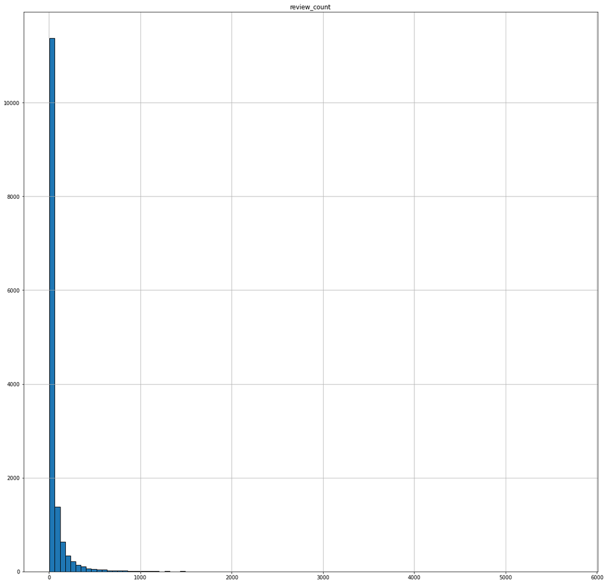

```python
#q1 no log scalling
df2.hist(column = "review_count",edgecolor='black', bins = 100 ,figsize = (20,20))
```

```
array([[<AxesSubplot:title={'center':'review_count'}>]], dtype=object)
```

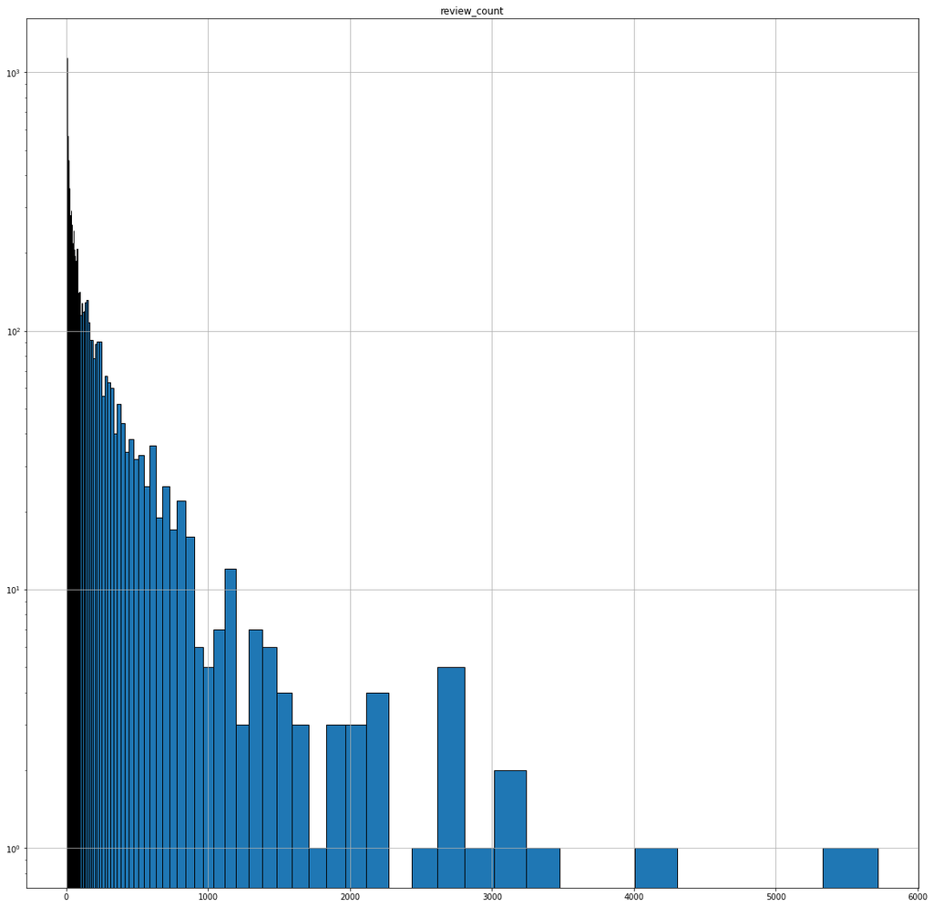

```python
#log scalling in bins
logbins = np.geomspace(df2["review_count"].min(), df2["review_count"].max(), 100)
df2.hist(column = "review_count",edgecolor='black', bins = logbins ,figsize = (20,20),log=True)
```

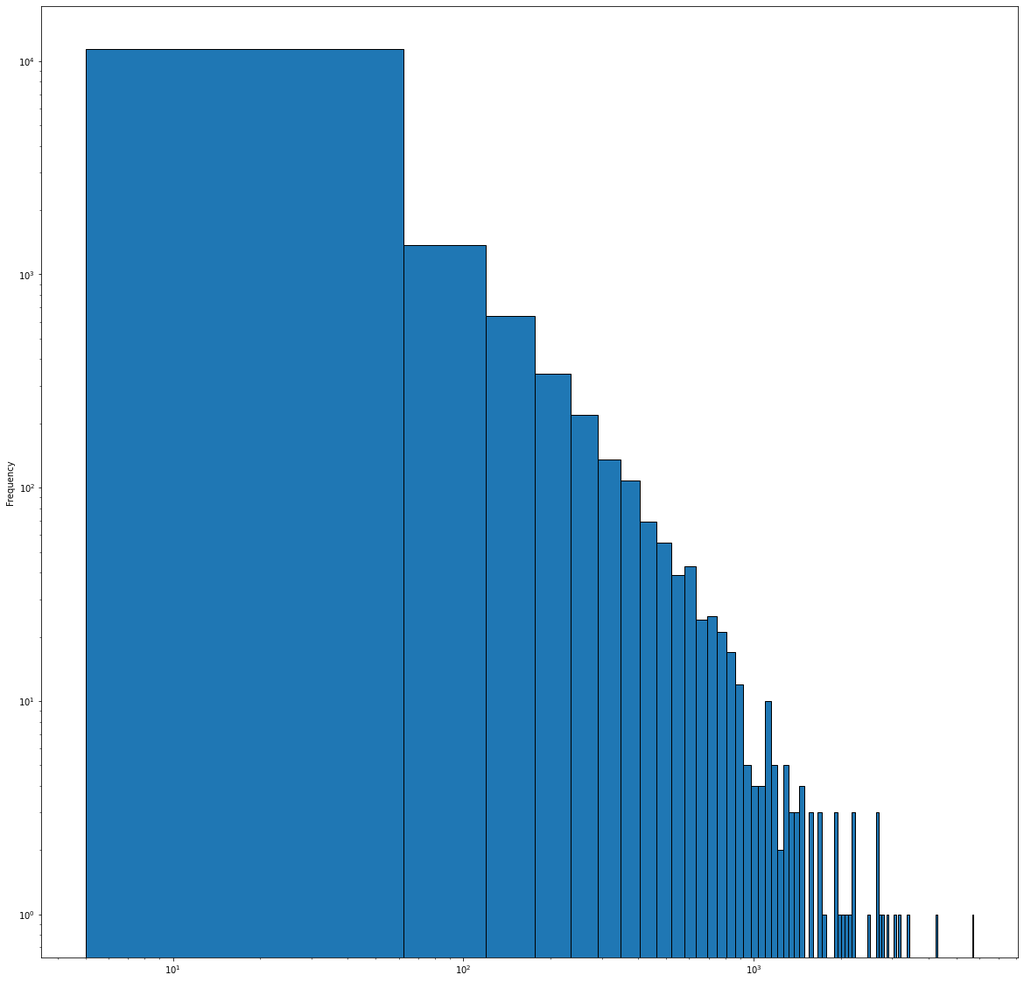

```python
#log scaling in x and y axis
df2["review_count"].plot.hist(bins = 100, logy=True , logx=True ,edgecolor='black',figsize = (20,20))
```

With the scaling , it shows that the distribution could be skewed to the right (positively skewed) but its not really evenly distributed but the range of the review counts is visible

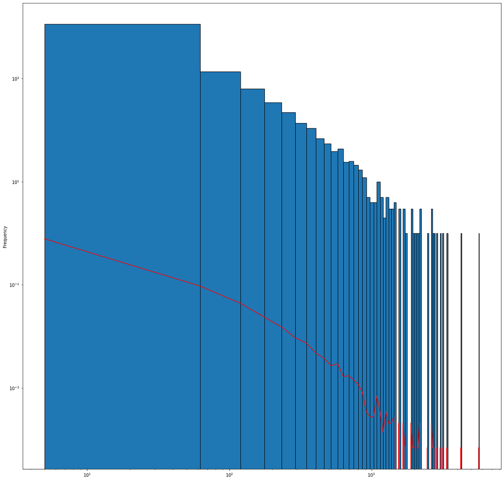

```python
#probability frequency of review_count
review_c = df2["review_count"].values.tolist()
#edges = np.histogram_bin_edges(review_c, bins=100)
hist,bins = np.histogram(review_c, bins=100, density=True)
pdf = hist/sum(hist)
plt.plot(bins[:-1],pdf[:],'r')
plt.xscale('log')
plt.yscale('log')
df2["review_count"].plot.hist(bins = 100, logy=True , logx=True ,edgecolor='black',figsize = (20,20))
plt.show()
```

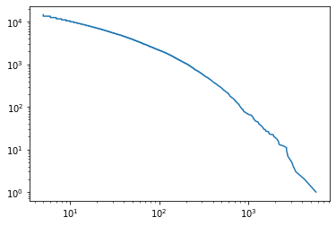

```python
#Zipf plot
rev_review_c = list(review_c)
rev_review_c.sort(reverse=True)
ranks = np.arange(start = 1 , stop = len(review_c))
plt.plot(rev_review_c[:-1],ranks)
plt.xscale('log')
plt.yscale('log')
plt.rcParams['figure.figsize'] = [20, 20]
plt.show()
```

```
                                       -Part B-
                            Ratings in the course of time
```

```python
df3 = pd.read_csv('yelp_academic_dataset_reviews.csv')
df3
```

|  | review_id | user_id | business_id | stars | useful | funny | cool | text | date |
| --- | --- | --- | --- | --- | --- | --- | --- | --- | --- |
| 0 | BiTunyQ73aT9WBnpR9DZGw | OyoGAe7OKpv6SyGZT5g77Q | 7ATYjTIgM3jUlt4UM3IypQ | 5 | 1 | 0 | 1 | I've taken a lot of spin classes over the year... | 2012-01-03 15:28:18 |
| 1 | AqPFMleE6RsU23_auESxiA | _7bHUi9Uuf5__HHc_Q8guQ | kxX2SOes4o-D3ZQBkiMRfA | 5 | 1 | 0 | 1 | Wow! Yummy, different, delicious. Our favo... | 2015-01-04 00:01:03 |
| 2 | JrIxlS1TzJ-iCu79ul40cQ | eUta8W_HdHMXPzLBBZhL1A | 04UD14gamNjLY0IDYVhHJg | 1 | 1 | 2 | 1 | I am a long term frequent customer of this est... | 2015-09-23 23:10:31 |
| 3 | 8JFGBuHMoiNDyfcxuWNtrA | smOvOajNG0lS4Pq7d8g4JQ | RZtGWDLCAtuipwaZ-UfjmQ | 4 | 0 | 0 | 0 | Good food--loved the gnocchi with marinara\nth... | 2009-10-14 19:57:14 |
| 4 | oyaMhzBSwfGgemSGuZCdwQ | Dd1jQj7S-BFGqRbApFzCFw | YtSqYv1Q_pOltsVPSx54SA | 5 | 0 | 0 | 0 | Tremendous service (Big shout out to Douglas) ... | 2013-06-24 11:21:25 |
| ... | ... | ... | ... | ... | ... | ... | ... | ... | ... |
| 967547 | tWCi4N2qCil876BI2NDAZg | 5d32aJe0a3_fSl3LIVYkWQ | EmrOCT7fArKI0JI_XF6aaw | 1 | 5 | 2 | 0 | Temple University blatantly disregards freedom... | 2021-08-28 18:46:05 |
| 967548 | nLjbVsETpqO17RbFcqskkA | am7-gkH_PDz598oTdYSD6A | 3gVSrS4kffGGZT8oXHsIcw | 3 | 2 | 0 | 2 | *Later Yelp* I've only been here once, but I l... | 2014-11-03 14:45:46 |
| 967549 | 99ylx-qPUSseITqBye2MpA | -AkziDwQ8hv2COTDBBUpig | aunmz06iWvo3bd6MMHEbqg | 3 | 0 | 0 | 0 | Philly has become a dangerous place with the m... | 2022-01-18 03:48:44 |
| 967550 | KlHxcAifUF5zDKpJCBrRsw | 7ziWZULyiZv2TesYNMFf4g | qQO7ErS_RAN4Vs1uX0L55Q | 4 | 1 | 0 | 0 | ice cream! ice cream sodas, sundaes!! \n\nwant... | 2012-10-21 04:08:40 |
| 967551 | cACxcUY_AIsQKkpDRXuqnw | MCzlzlOw7IGbRAKVjJBPtg | fcGexL5VH5G2Xw0tRj9uOQ | 3 | 1 | 1 | 0 | This is a good pizza option - they deliver thr... | 2018-03-13 13:54:48 |

967552 rows × 9 columns

```python
df4 =df3.groupby(["business_id",], as_index=False)["date"].min()
df4['date']
```

```
0        2016-01-18 15:35:18
1        2008-10-01 19:40:48
2        2012-02-10 04:00:49
3        2009-10-16 15:24:48
4        2013-06-01 01:47:50
                ...
14564    2011-06-15 22:29:56
14565    2012-05-31 23:02:37
14566    2011-11-17 17:08:56
14567    2007-05-02 13:35:25
14568    2014-03-26 16:55:46
Name: date, Length: 14569, dtype: object
```

Adding the 1st review date to the df and with datetime library The month difference/distance is also added

```python
import datetime
df3['date']= pd.to_datetime(df3['date'])
df3['date1'] = df3['business_id'].map(df4.set_index('business_id')['date'])
df3['date1']= pd.to_datetime(df3['date1'])

df3['month_diff'] = ((df3.date - df3.date1)/np.timedelta64(1, 'M'))
df3['month_diff'] = df3['month_diff'].astype(int)
```

```python
df3
```

|  | review_id | user_id | business_id | stars | useful | funny | cool | text | date | date1 | month_diff |
| --- | --- | --- | --- | --- | --- | --- | --- | --- | --- | --- | --- |
| 0 | BiTunyQ73aT9WBnpR9DZGw | OyoGAe7OKpv6SyGZT5g77Q | 7ATYjTIgM3jUlt4UM3IypQ | 5 | 1 | 0 | 1 | I've taken a lot of spin classes over the year... | 2012-01-03 15:28:18 | 2010-11-30 01:32:21 | 13 |
| 1 | AqPFMleE6RsU23_auESxiA | _7bHUi9Uuf5__HHc_Q8guQ | kxX2SOes4o-D3ZQBkiMRfA | 5 | 1 | 0 | 1 | Wow! Yummy, different, delicious. Our favo... | 2015-01-04 00:01:03 | 2010-08-20 19:16:04 | 52 |
| 2 | JrIxlS1TzJ-iCu79ul40cQ | eUta8W_HdHMXPzLBBZhL1A | 04UD14gamNjLY0IDYVhHJg | 1 | 1 | 2 | 1 | I am a long term frequent customer of this est... | 2015-09-23 23:10:31 | 2006-12-18 23:20:04 | 105 |
| 3 | 8JFGBuHMoiNDyfcxuWNtrA | smOvOajNG0lS4Pq7d8g4JQ | RZtGWDLCAtuipwaZ-UfjmQ | 4 | 0 | 0 | 0 | Good food--loved the gnocchi with marinara\nth... | 2009-10-14 19:57:14 | 2006-12-22 04:19:02 | 33 |
| 4 | oyaMhzBSwfGgemSGuZCdwQ | Dd1jQj7S-BFGqRbApFzCFw | YtSqYv1Q_pOltsVPSx54SA | 5 | 0 | 0 | 0 | Tremendous service (Big shout out to Douglas) ... | 2013-06-24 11:21:25 | 2005-09-23 13:05:56 | 93 |
| ... | ... | ... | ... | ... | ... | ... | ... | ... | ... | ... | ... |
| 967547 | tWCi4N2qCil876BI2NDAZg | 5d32aJe0a3_fSl3LIVYkWQ | EmrOCT7fArKI0JI_XF6aaw | 1 | 5 | 2 | 0 | Temple University blatantly disregards freedom... | 2021-08-28 18:46:05 | 2007-01-25 03:05:37 | 175 |
| 967548 | nLjbVsETpqO17RbFcqskkA | am7-gkH_PDz598oTdYSD6A | 3gVSrS4kffGGZT8oXHsIcw | 3 | 2 | 0 | 2 | *Later Yelp* I've only been here once, but I l... | 2014-11-03 14:45:46 | 2005-09-26 12:39:58 | 109 |
| 967549 | 99ylx-qPUSseITqBye2MpA | -AkziDwQ8hv2COTDBBUpig | aunmz06iWvo3bd6MMHEbqg | 3 | 0 | 0 | 0 | Philly has become a dangerous place with the m... | 2022-01-18 03:48:44 | 2010-09-26 16:20:34 | 135 |
| 967550 | KlHxcAifUF5zDKpJCBrRsw | 7ziWZULyiZv2TesYNMFf4g | qQO7ErS_RAN4Vs1uX0L55Q | 4 | 1 | 0 | 0 | ice cream! ice cream sodas, sundaes!! \n\nwant... | 2012-10-21 04:08:40 | 2006-05-30 06:00:33 | 76 |
| 967551 | cACxcUY_AIsQKkpDRXuqnw | MCzlzlOw7IGbRAKVjJBPtg | fcGexL5VH5G2Xw0tRj9uOQ | 3 | 1 | 1 | 0 | This is a good pizza option - they deliver thr... | 2018-03-13 13:54:48 | 2009-10-16 21:52:38 | 100 |

967552 rows × 11 columns

```python
df5 = df3.groupby(["month_diff",], as_index=False)["stars"].mean()
df5
```

|  | month_diff | stars |
| --- | --- | --- |
| 0 | 0 | 3.982224 |
| 1 | 1 | 3.993584 |
| 2 | 2 | 3.982042 |
| 3 | 3 | 3.959054 |
| 4 | 4 | 3.936018 |
| ... | ... | ... |
| 198 | 198 | 3.683333 |
| 199 | 199 | 3.870370 |
| 200 | 200 | 2.454545 |
| 201 | 201 | 2.692308 |
| 202 | 202 | 3.666667 |

203 rows × 2 columns

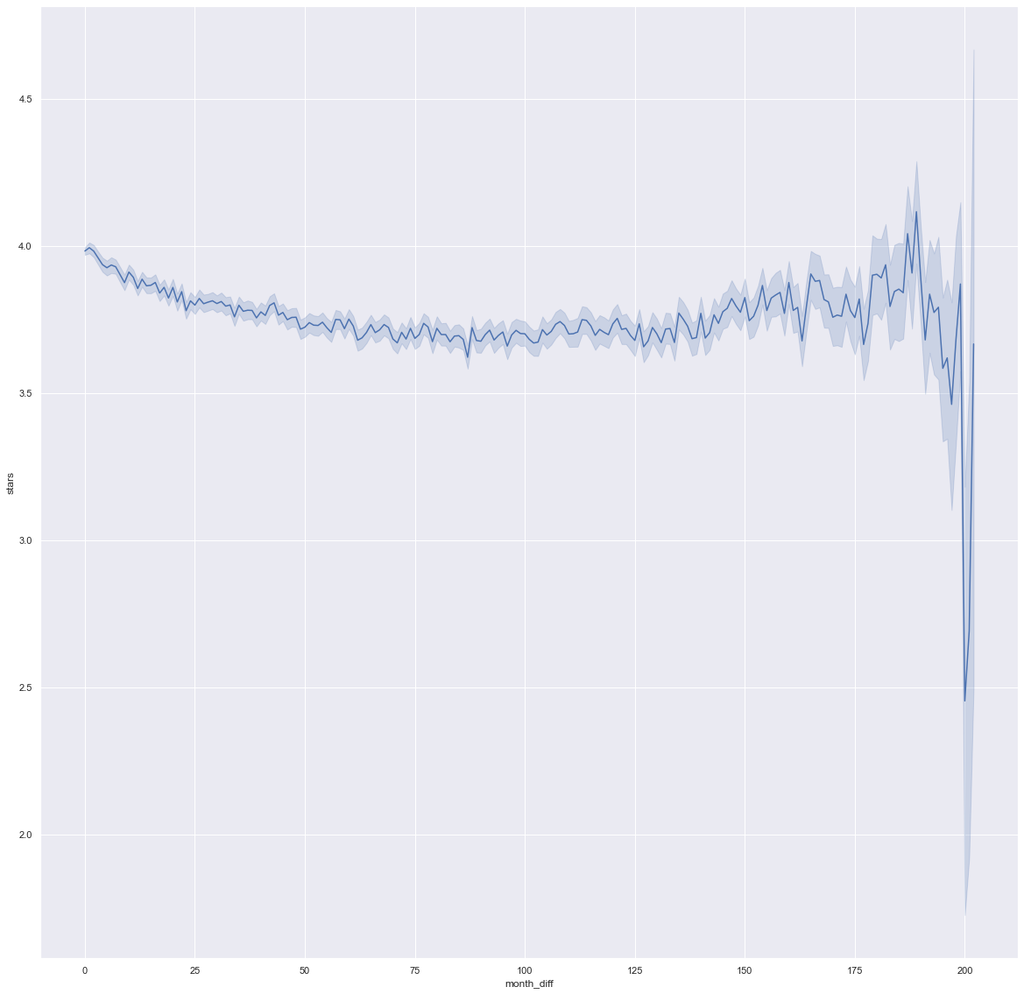

```python
sns.set_theme(style="darkgrid")
sns.lineplot(data=df3 ,x = "month_diff", y = "stars",errorbar =("ci",95))
```

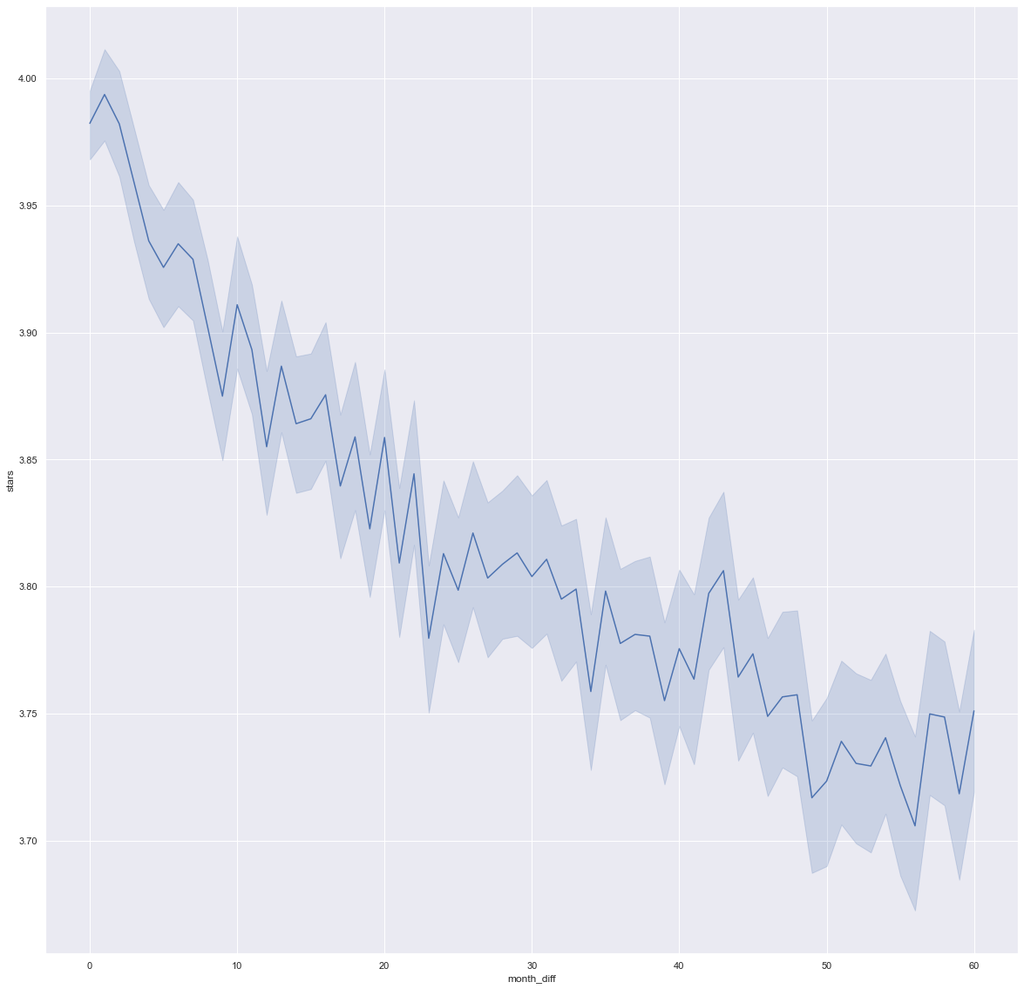

```python
sns.set_theme(style="darkgrid")
sns.lineplot(data =df3[(df3['month_diff'] >= 0) & (df3['month_diff'] <= 60)], x = "month_diff", y = "stars",errorbar =("ci",95))
```

The avarage rating in the course of 5 years shows a slight drop. This makes sense since when a new business opens, people from all socioeconomic classes visit until a comperable amount of reviews start to show thus advising people into making more fitted decisions

```
                                    -Part C-
                 Factoring Businesses in how expensive an area is
```

```python
df4 = pd.read_table('RedfinPhila.tsv')
len(df4)
```

```
45244
```

```python
df4 = df4[['region', 'median_sale_price']]
len(df4)
```

```
45244
```

```python
df5 =df4.groupby(["region"], as_index=False)["median_sale_price"].median()
```

```python
#manipulate 'region' to fit with the postal_code from the other dataframe
df5['region'] = df5['region'].astype('str').str.extractall('(\d+)').unstack().fillna('').sum(axis=1).astype(int)
df5 = df5.rename(columns={'region': 'postal_code'})
df5
```

|  | postal_code | median_sale_price |
| --- | --- | --- |
| 0 | 19003 | 310000.0 |
| 1 | 19008 | 323000.0 |
| 2 | 19010 | 466250.0 |
| 3 | 19013 | 40000.0 |
| 4 | 19014 | 202062.5 |
| ... | ... | ... |
| 101 | 44680 | 161075.0 |
| 102 | 44681 | 154500.0 |
| 103 | 44682 | 94000.0 |
| 104 | 44683 | 72900.0 |
| 105 | 44697 | 219500.0 |

106 rows × 2 columns

```python
df2 = df2[df2['postal_code'].notnull()]
df2['postal_code'] = df2['postal_code'].apply(np.int64)
df10 =df2.groupby(["postal_code"], as_index=False)["business_id"].count()
df10 = df10.rename(columns={'business_id': 'business_sum'})
```

```python
df11 =df2.groupby(["postal_code"], as_index=False)["stars"].mean()
df11 = df11.merge(df10, on='postal_code')
```

```python
df5 = df5.merge(df11, on='postal_code')
```

```python
len(df5)
```

```
53
```

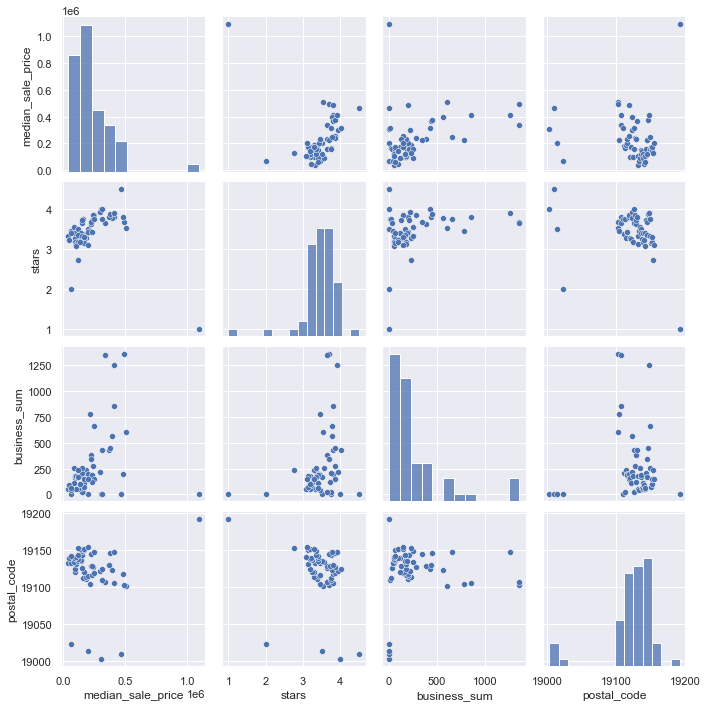

```python
sns.pairplot(df5,kind='scatter',x_vars=["median_sale_price", "stars", "business_sum",'postal_code'],
    y_vars=["median_sale_price", "stars","business_sum",'postal_code'],)
```

```python
df5[['median_sale_price','stars','business_sum']].corr()
```

|  | median_sale_price | stars | business_sum |
| --- | --- | --- | --- |
| median_sale_price | 1.000000 | -0.126896 | 0.337079 |
| stars | -0.126896 | 1.000000 | 0.288593 |
| business_sum | 0.337079 | 0.288593 | 1.000000 |

```python
#from stackoverflow
def calculate_pvalues(df):
    dfcols = pd.DataFrame(columns=df.columns)
    pvalues = dfcols.transpose().join(dfcols, how='outer')
    for r in df.columns:
        for c in df.columns:
            tmp = df[df[r].notnull() & df[c].notnull()]
            pvalues[r][c] = round(stats.pearsonr(tmp[r], tmp[c])[1], 4)
    return pvalues
```

```python
calculate_pvalues(df5[['median_sale_price','stars','business_sum']])
```

|  | median_sale_price | stars | business_sum |
| --- | --- | --- | --- |
| median_sale_price | 0.0 | 0.3652 | 0.0136 |
| stars | 0.3652 | 0.0 | 0.0361 |
| business_sum | 0.0136 | 0.0361 | 0.0 |

Interesting correlations : median_sale_price - business_sum and also stars- business have a small association The fist correletion if we take a look into the plots(x:median_sale_price, y:business_sum) and (y:business_sum and y:median_sale_price) are almost identical which shows that the less the businesses the less expensive the area is . But if we view the plot (y:median_sale_price and y:stars) it shows that higher stars get businesses with less nedian_sale_price That can indicate that the second part of the hypothesis might not be correct (H: Expensive areas have more and better businesses)

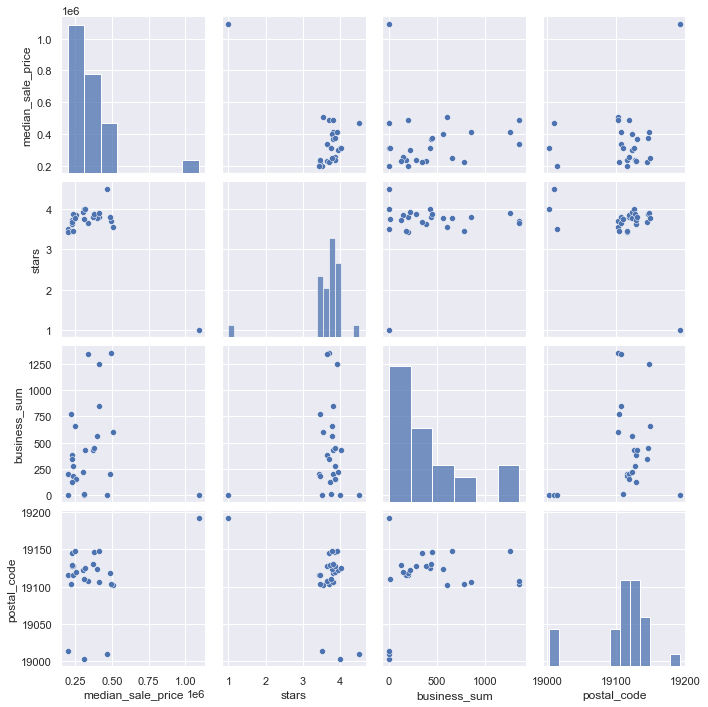

```python
sns.pairplot(df5[df5.median_sale_price > 200000],kind='scatter',x_vars=["median_sale_price", "stars", "business_sum",'postal_code'],
    y_vars=["median_sale_price", "stars","business_sum",'postal_code'])
```

```python
df6 = df5.loc[df5['median_sale_price'] > 200000]
len(df6)
```

```
25
```

```python
df6[['median_sale_price','stars','business_sum']].corr()
```

|  | median_sale_price | stars | business_sum |
| --- | --- | --- | --- |
| median_sale_price | 1.000000 | -0.698818 | 0.015466 |
| stars | -0.698818 | 1.000000 | 0.137097 |
| business_sum | 0.015466 | 0.137097 | 1.000000 |

```python
calculate_pvalues(df6[['median_sale_price','stars','business_sum']])
```

|  | median_sale_price | stars | business_sum |
| --- | --- | --- | --- |
| median_sale_price | 0.0 | 0.0001 | 0.9415 |
| stars | 0.0001 | 0.0 | 0.5134 |
| business_sum | 0.9415 | 0.5134 | 0.0 |

In the nost expensive part of the experiment (keeping only the 200k median sale price) There is a strong negative correlations between stars- median_sale_price this further confirms that the second part of the hypothesis is not correct as we can also see from the (y:stars , x:median_sale_price) Also the p-value in (business_summ - median_sale_price) is very high making the null hypothesis cannot be rejected and also stars- business have a small association but with high p-value. With these correspondes and p-values we cannot reject our first part of the hypothesis but can accept the hypothesis that less expensive areas have less businesses

```
                                  - Part D -
              Star Rating Diference between price and dress code
```

```python
#Focusing only on Restaurants
df2 = pd.read_csv('yelp_academic_dataset_business.csv')
df2 = df2[df2['categories'].notnull()]
df_d1 = df2.loc[df2['categories'].str.contains("Restaurants")]
#df_d1.reset_index(inplace = True)
len(df_d1)
```

```
5852
```

```python
#tested 1by1 untli i found the 1st error it was about the nan values
#attributes was not normalized from the json -> csv conversion
attributes_list = df_d1['attributes'].values.tolist()
attributes_dict = []
for i in range(len(attributes_list)):
    if attributes_list[i] is attributes_list[15] :
        attributes_dict.append({})
    else:
       # print(i)
        attributes_dict.append(ast.literal_eval(attributes_list[i]))
```

```python
attributes_dict[1090]['RestaurantsPriceRange2'] #coudn't find whitch none-value triggers
                                                #the if function (cell above)
```

```
'None'
```

```python
restaurantsPriceRange= []
for i in range(len(attributes_dict)):
    if 'RestaurantsPriceRange2' not in attributes_dict[i]:
        attributes_dict[i]['RestaurantsPriceRange2'] = 0
    elif attributes_dict[i]['RestaurantsPriceRange2'] == 'None' :
        attributes_dict[i]['RestaurantsPriceRange2'] = 0
    #print(i)
    restaurantsPriceRange.append(int(attributes_dict[i]['RestaurantsPriceRange2']))
```

```python
restaurantsPriceType=[]
for i in range(len(restaurantsPriceRange)):
    if restaurantsPriceRange[i] == 1 or restaurantsPriceRange[i] == 2:
        restaurantsPriceType.append('Cheap')
    elif restaurantsPriceRange[i] == 3 or restaurantsPriceRange[i] == 4:
        restaurantsPriceType.append('Expensive')
    else:
        restaurantsPriceType.append('No Value')
```

```python
#df_d1['restaurantsPriceType']= restaurantsPriceType
df_d1['restaurantsPriceRange']= restaurantsPriceRange
```

```python
len(df_d1)
```

```
5852
```

```python
df_d2 = df_d1.loc[df_d1.restaurantsPriceRange <= 4]
df_d3 = df_d2["stars"].mean()
df_d3
```

```
3.555963773069036
```

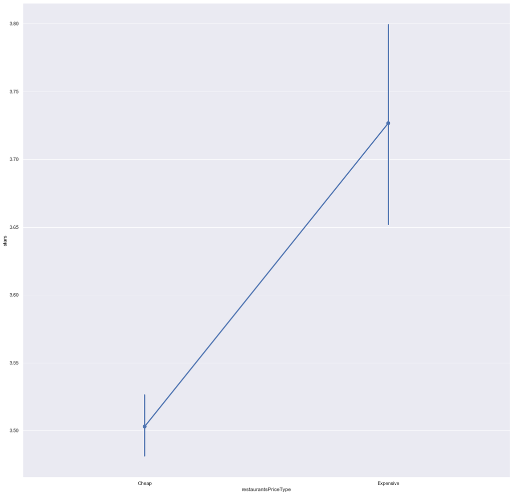

```python
sns.set_theme(style="darkgrid")
#data=df_d1[(df_d1['restaurantsPriceRange'] >= 1) & (df_d1['restaurantsPriceRange'] <= 4)]
sns.pointplot(data=df_d1[df_d1['restaurantsPriceType'] != 'No Value'],x='restaurantsPriceType', y = "stars",errorbar =("ci",95),join=True)
```

from the plot is visible that cheaper restaurants have lower mean.star rating and more expensive restaurants have higher star rating.

```python
stars1 = df_d1[df_d1['restaurantsPriceType']== "Cheap"]
stars2 = df_d1[df_d1['restaurantsPriceType']== "Expensive"]
ttest_val , p =ttest_ind(stars1['stars'], stars2['stars'])
print('t.value='+"%.10f" % ttest_val+'  p.value='+ "%.10f" % p)
```

```
t.value=-4.7542266203  p.value=0.0000020487
```

Since the p.value the null hypothesis is rejected so the negative sign of the t.value can be ignored .But the t.value is bigger than the mean of star ratings so it has some statistical importance

```python
restaurantAttire= []
for i in range(len(attributes_dict)):
    if 'RestaurantsAttire' not in attributes_dict[i]:
        attributes_dict[i]['RestaurantsAttire'] = 0
    elif attributes_dict[i]['RestaurantsAttire'] == 'None' :
        attributes_dict[i]['RestaurantsAttire'] = 0
    elif attributes_dict[i]['RestaurantsAttire'] == "'casual'" or attributes_dict[i]['RestaurantsAttire'] == "u'casual'" :
        restaurantAttire.append("casual")
    elif attributes_dict[i]['RestaurantsAttire'] == "u'dressy'" or attributes_dict[i]['RestaurantsAttire'] == "'dressy'" :
        restaurantAttire.append("dressy")
    elif attributes_dict[i]['RestaurantsAttire'] == "u'formal'" or attributes_dict[i]['RestaurantsAttire'] == "'formal'" :
        restaurantAttire.append("dressy")
    else:
        restaurantAttire.append(str(attributes_dict[i]['RestaurantsAttire']))
```

```python
len(restaurantAttire)
df_d1['restaurantsAttire']= restaurantAttire
len(df_d1)
#len(attributes_dict)
```

```
5852
```

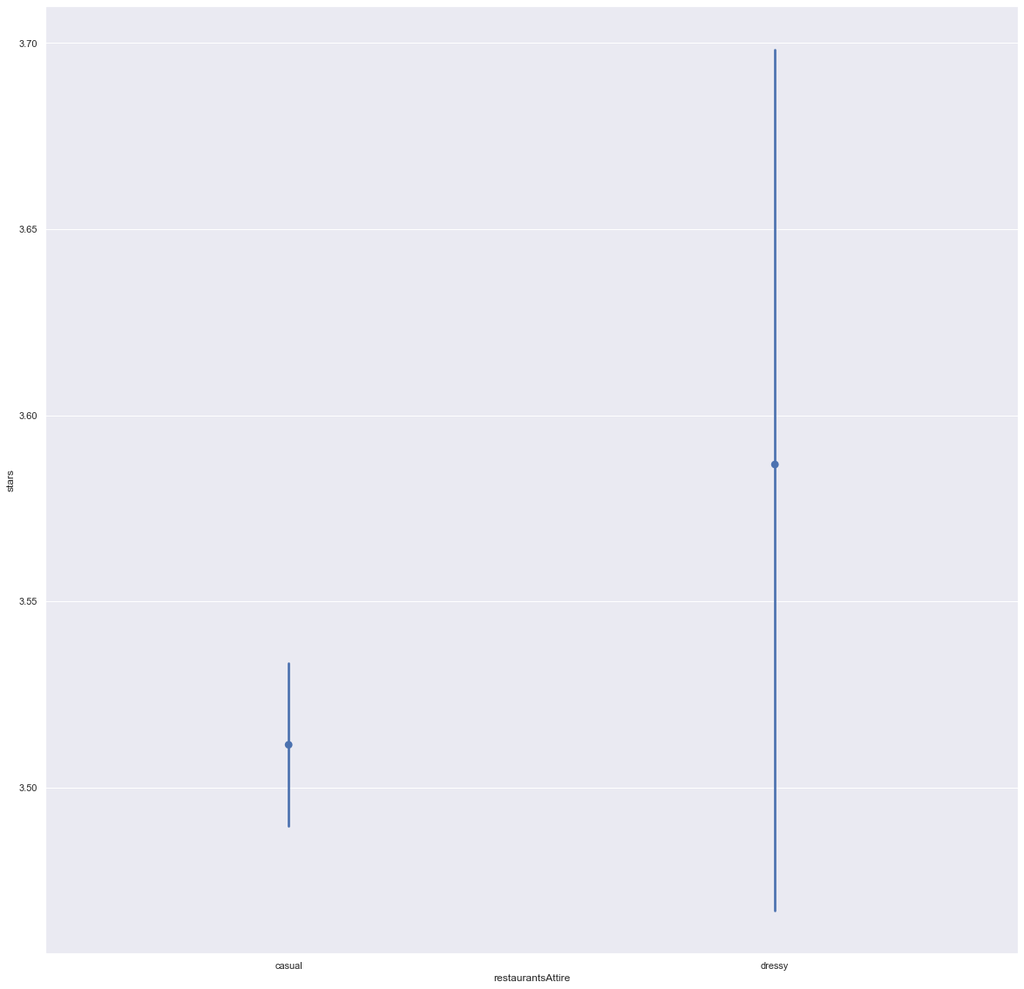

```python
sns.set_theme(style="darkgrid")
sns.pointplot(data=df_d1[df_d1['restaurantsAttire'].str.contains("cas|dress") ] ,x = "restaurantsAttire", y = "stars",errorbar =("ci",95),join=False)
```

```python
stars1 = df_d1[df_d1['restaurantsAttire']== "casual"]
stars2 = df_d1[df_d1['restaurantsAttire']== "dressy"]
ttest_val , p =ttest_ind(stars1['stars'], stars2['stars'])
print('t.value='+"%.10f" % ttest_val+'  p.value='+ "%.10f" % p)
```

```
t.value=-1.0919522455  p.value=0.2749145789
```

When talking about dresscode we can see from the plot that there are better ratings when it comes to if the restaurant is more dressy but taking into consideration the ttest we can reject that hypothesis.Since p.value is high (95% confidence interval) and the t.value isnt greater than the mean of star rating

```
                                 -Part E-
                 Correlation between restaurant characteristics
```

```python
attributes_dict[1]['Ambience']
```

```
"{'touristy': False, 'hipster': False, 'romantic': False, 'divey': False, 'intimate': False, 'trendy': False, 'upscale': False, 'classy': True, 'casual': False}"
```

```python
for i in range(len(attributes_dict)):
    if 'Ambience' not in attributes_dict[i]:
        attributes_dict[i]['Ambience'] = "StrNoneFlag"
    elif not attributes_dict[i]['Ambience']:
        attributes_dict[i]['Ambience'] = "StrNoneFlag"
        print(attributes_dict[i]['Ambience'])
    elif attributes_dict[i]['Ambience'] == 'None':
        attributes_dict[i]['Ambience'] = "StrNoneFlag"
    else:
        attributes_dict[i]['Ambience'] = ast.literal_eval(attributes_dict[i]['Ambience'])
```

```python
date_frndly= []
boojie = []
for i in range(len(attributes_dict)):
    if ('romantic' not in attributes_dict[i]['Ambience']) or ('intimate' not in attributes_dict[i]['Ambience']):
        date_frndly.append(0)
    elif attributes_dict[i]['Ambience'] == "StrNoneFlag":
        date_frndly.append(0)
    elif (attributes_dict[i]['Ambience']['romantic'] == True) or (attributes_dict[i]['Ambience']['intimate'] == True) :
        date_frndly.append(1)
    else:
        date_frndly.append(0)

    if ('classy' not in attributes_dict[i]['Ambience']) or('upscale' not in attributes_dict[i]['Ambience']) or (attributes_dict[0]['Ambience'] == 'None'):
        boojie.append(0)
    elif attributes_dict[i]['Ambience'] == "StrNoneFlag":
        date_frndly.append(0)
    elif (attributes_dict[i]['Ambience']['classy'] == True) or (attributes_dict[i]['Ambience']['upscale'] == True) :
        boojie.append(1)
    else:
        boojie.append(0)
```

```python
df_d1['dateFriendly']= date_frndly
df_d1['classy']= boojie
df_d1
```

|  | business_id | name | address | city | state | postal_code | latitude | longitude | stars | review_count | is_open | attributes | categories | hours | restaurantsPriceType | restaurantsPriceRange | restaurantsAttire | dateFriendly | classy |
| --- | --- | --- | --- | --- | --- | --- | --- | --- | --- | --- | --- | --- | --- | --- | --- | --- | --- | --- | --- |
| 0 | MTSW4McQd7CbVtyjqoe9mw | St Honore Pastries | 935 Race St | Philadelphia | PA | 19107.0 | 39.955505 | -75.155564 | 4.0 | 80 | 1 | {'RestaurantsDelivery': 'False', 'OutdoorSeati... | Restaurants, Food, Bubble Tea, Coffee & Tea, B... | {'Monday': '7:0-20:0', 'Tuesday': '7:0-20:0', ... | Cheap | 1 | 0 | 0 | 0 |
| 1 | MUTTqe8uqyMdBl186RmNeA | Tuna Bar | 205 Race St | Philadelphia | PA | 19106.0 | 39.953949 | -75.143226 | 4.0 | 245 | 1 | {'RestaurantsReservations': 'True', 'Restauran... | Sushi Bars, Restaurants, Japanese | {'Tuesday': '13:30-22:0', 'Wednesday': '13:30-... | Cheap | 2 | casual | 0 | 1 |
| 2 | ROeacJQwBeh05Rqg7F6TCg | BAP | 1224 South St | Philadelphia | PA | 19147.0 | 39.943223 | -75.162568 | 4.5 | 205 | 1 | {'NoiseLevel': "u'quiet'", 'GoodForMeal': "{'d... | Korean, Restaurants | {'Monday': '11:30-20:30', 'Tuesday': '11:30-20... | Cheap | 1 | casual | 0 | 0 |
| 3 | QdN72BWoyFypdGJhhI5r7g | Bar One | 767 S 9th St | Philadelphia | PA | 19147.0 | 39.939825 | -75.157447 | 4.0 | 65 | 0 | {'Smoking': "u'no'", 'NoiseLevel': "u'average'... | Cocktail Bars, Bars, Italian, Nightlife, Resta... | {'Monday': '16:0-0:0', 'Tuesday': '16:0-0:0', ... | Cheap | 2 | casual | 0 | 0 |
| 4 | Mjboz24M9NlBeiOJKLEd_Q | DeSandro on Main | 4105 Main St | Philadelphia | PA | 19127.0 | 40.022466 | -75.218314 | 3.0 | 41 | 0 | {'RestaurantsReservations': 'False', 'Caters':... | Pizza, Restaurants, Salad, Soup | {'Tuesday': '17:0-21:30', 'Wednesday': '17:0-1... | Cheap | 1 | casual | 0 | 0 |
| ... | ... | ... | ... | ... | ... | ... | ... | ... | ... | ... | ... | ... | ... | ... | ... | ... | ... | ... | ... |
| 14559 | VZbkSeZtFynEascotq7ExA | Ali Baba Magic Food | 37TH And Walnut | Philadelphia | PA | 19104.0 | 39.953391 | -75.196765 | 4.0 | 8 | 0 | {'GoodForKids': 'False', 'RestaurantsReservati... | Restaurants, Food Stands | NaN | Cheap | 1 | casual | 0 | 0 |
| 14561 | gPr1io7ks0Eo3FDsnDTYfg | Tata Cafe | 7201 Germantown Ave | Philadelphia | PA | 19119.0 | 40.060414 | -75.191084 | 4.0 | 21 | 0 | {'RestaurantsGoodForGroups': 'True', 'Business... | Sandwiches, Restaurants, Italian | {'Monday': '7:0-17:0', 'Tuesday': '7:0-17:0', ... | Cheap | 1 | casual | 1 | 0 |
| 14562 | wVxXRFf10zTTAs11nr4xeA | PrimoHoagies | 6024 Ridge Ave | Philadelphia | PA | 19128.0 | 40.032483 | -75.214430 | 3.0 | 55 | 1 | {'NoiseLevel': "u'average'", 'RestaurantsTakeO... | Restaurants, Specialty Food, Food, Sandwiches,... | {'Monday': '10:0-21:0', 'Tuesday': '10:0-21:0'... | Cheap | 2 | casual | 0 | 0 |
| 14563 | 8n93L-ilMAsvwUatarykSg | Kitchen Gia | 3716 Spruce St | Philadelphia | PA | 19104.0 | 39.951018 | -75.198240 | 3.0 | 22 | 0 | {'RestaurantsGoodForGroups': 'True', 'BikePark... | Coffee & Tea, Food, Sandwiches, American (Trad... | {'Monday': '9:0-19:30', 'Tuesday': '9:0-19:30'... | Cheap | 2 | casual | 0 | 0 |
| 14568 | WnT9NIzQgLlILjPT0kEcsQ | Adelita Taqueria & Restaurant | 1108 S 9th St | Philadelphia | PA | 19147.0 | 39.935982 | -75.158665 | 4.5 | 35 | 1 | {'WheelchairAccessible': 'False', 'Restaurants... | Restaurants, Mexican | {'Monday': '11:0-22:0', 'Tuesday': '11:0-22:0'... | Cheap | 2 | casual | 0 | 0 |

5852 rows × 19 columns

```python
contingency_table=pd.crosstab(df_d1['classy'],df_d1['dateFriendly'])
contingency_table
```

| dateFriendly classy | 0 | 1 |
| --- | --- | --- |
| 0 | 4922 | 113 |
| 1 | 712 | 105 |

```python
contigency_pct = pd.crosstab(df_d1['classy'],df_d1['dateFriendly'], normalize='columns')#percentages by columns
contigency_pct
```

| dateFriendly classy | 0 | 1 |
| --- | --- | --- |
| 0 | 0.873624 | 0.518349 |
| 1 | 0.126376 | 0.481651 |

```python
import scipy.stats
chi2, p, dof, expected = chi2_contingency(contingency_table)
```

```python
print("p_value is:"+"%.50f" % p)
```

```
p_value is:0.00000000000000000000000000000000000000000000000030
```

```python
chi2
```

```
217.59222720699026
```

from the formula h = Σ((O-E)^2)/2

```python
h= 105*0.481651
h
```

```
50.573355
```

```python
chi2 >= h
```

```
True
```

```python
expected
```

```
array([[4847.43506494,  187.56493506],
       [ 786.56493506,   30.43506494]])
```

```
                                  -Part Z -
                   appearance frequency  business categories
                in corellation with their price range of the area
```

```python
df_z1 = pd.read_csv('yelp_academic_dataset_business.csv')
df_z1 = df_z1[df_z1['categories'].notnull()]
df_z2 = df_z1.groupby(['postal_code'])['categories'].apply(list).reset_index()
```

```python
df_z2
```

|  | postal_code | categories |
| --- | --- | --- |
| 0 | 8102.0 | [Automotive, Local Flavor, Active Life, Landma... |
| 1 | 8340.0 | [Food, Food Trucks] |
| 2 | 18976.0 | [Makeup Artists, Beauty & Spas] |
| 3 | 19003.0 | [Contractors, Local Services, Home Services, P... |
| 4 | 19004.0 | [Food Trucks, Food, Cupcakes, Street Vendors] |
| ... | ... | ... |
| 84 | 19444.0 | [Specialty Food, Desserts, Cupcakes, Bakeries,... |
| 85 | 19446.0 | [Flooring, Tiling, Home & Garden, Kitchen & Ba... |
| 86 | 19454.0 | [Thai, Restaurants, Vietnamese] |
| 87 | 43215.0 | [Local Flavor, Party & Event Planning, Event P... |
| 88 | 55101.0 | [Wedding Planning, Photographers, DJs, Event P... |

89 rows × 2 columns

```python
cat_dump = df_z2['categories'].values.tolist()
```

```python
cat_dump_fltn = []
temp =[]
for i in range(len(cat_dump)):
    temp = []
    for j in range(len(cat_dump[i])):
        comma_whitespace_sep = [x.strip() for x in (cat_dump[i][j]).split(',')]
        temp = temp + comma_whitespace_sep
    cat_dump_fltn.append(temp)
    del temp
```

```python
from collections import Counter
len(cat_dump_fltn)
```

```
89
```

```python
from collections import Counter
counts = []
for i in range(len(cat_dump_fltn)):
    counts.append(Counter(cat_dump_fltn[i]))
    if ('Restaurants' not in attributes_dict[i]):
        continue
    counts[i].pop('Restaurants')
len(counts)
```

```
89
```

```python
len(counts[0])
```

```
5
```

-Wannabe Dimention Reduction- For the experiment , valuing the variety of buisinesses will be important since zoning laws in north America are strict and thus "walkable" regions becoming more attractive and thus more expensive The areas where there is some history tend to be attractive Also if an area has establishment about culture , arts , museums in becomes more attractive finaly if the area has a lot of ofices , banks , law firms etc accessible areas are also appealing thats why transportation is a factor . The weight on each factor will be the same for simplicity purposes .

```python
score=[0]*len(counts)
variety_factor = [0]*len(counts)
for i in range(len(counts)):
    if ('Art Galleries' in counts[i]) or ('Museums' in counts[i]) or ('Arts & Entertainment' in counts[i]) or ('Performing Arts' in counts[i]):
        score[i]= score[i] + 1
    if ('Banks & Credit Unions' in counts[i]) or ('Financial Services' in counts[i]) or ('Real Estate Law' in counts[i]) or ('Business Law' in counts[i]) or ('Bankruptcy Law' in counts[i]) or ('Tax Law' in counts[i]) or ('Lawyers' in counts[i]):
        score[i]= score[i] + 1
    if ('Landmarks & Historical Buildings' in counts[i]) or ('Transportation' in counts[i])  or ('Public Services & Government' in counts[i]) :
        score[i]= score[i] + 1
    variety_factor[i] = variety_factor[i] + len(counts[i])
```

```python
#normalizing variety_factor
final_score=[0]*len(counts)
vf_min, vf_max = min(variety_factor) , max(variety_factor)
for i,val in enumerate(variety_factor):
    variety_factor[i] = (val-vf_min)/(vf_max-vf_min)
    final_score[i]= score[i] + variety_factor[i]
```

```python
df_z2['myFreqAp_apprnc_score'] = final_score
df_z2
```

|  | postal_code | categories | myFreqAp_apprnc_score |
| --- | --- | --- | --- |
| 0 | 8102.0 | [Automotive, Local Flavor, Active Life, Landma... | 1.005217 |
| 1 | 8340.0 | [Food, Food Trucks] | 0.000000 |
| 2 | 18976.0 | [Makeup Artists, Beauty & Spas] | 0.000000 |
| 3 | 19003.0 | [Contractors, Local Services, Home Services, P... | 0.006957 |
| 4 | 19004.0 | [Food Trucks, Food, Cupcakes, Street Vendors] | 0.003478 |
| ... | ... | ... | ... |
| 84 | 19444.0 | [Specialty Food, Desserts, Cupcakes, Bakeries,... | 0.005217 |
| 85 | 19446.0 | [Flooring, Tiling, Home & Garden, Kitchen & Ba... | 0.012174 |
| 86 | 19454.0 | [Thai, Restaurants, Vietnamese] | 0.001739 |
| 87 | 43215.0 | [Local Flavor, Party & Event Planning, Event P... | 1.005217 |
| 88 | 55101.0 | [Wedding Planning, Photographers, DJs, Event P... | 0.003478 |

89 rows × 3 columns

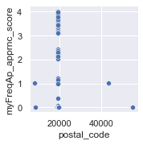

```python
sns.pairplot(df_z2,kind='scatter',x_vars=["postal_code"],
    y_vars=["myFreqAp_apprnc_score"])
```

```python
df_z3 =df4.groupby(["region"], as_index=False)["median_sale_price"].mean()
df_z3['region'] = df_z3['region'].astype('str').str.extractall('(\d+)').unstack().fillna('').sum(axis=1).astype(int)
df_z3 = df_z3.rename(columns={'region': 'postal_code'})
df_z3
```

|  | postal_code | median_sale_price |
| --- | --- | --- |
| 0 | 19003 | 348269.932594 |
| 1 | 19008 | 309258.622892 |
| 2 | 19010 | 469248.786871 |
| 3 | 19013 | 52576.980159 |
| 4 | 19014 | 207546.861213 |
| ... | ... | ... |
| 101 | 44680 | 163104.027778 |
| 102 | 44681 | 160778.439441 |
| 103 | 44682 | 97083.503401 |
| 104 | 44683 | 74737.369369 |
| 105 | 44697 | 231157.692308 |

106 rows × 2 columns

```python
df_z2 = df_z2.merge(df_z3, on='postal_code')

df_z2
```

|  | postal_code | categories | myFreqAp_apprnc_score | median_sale_price |
| --- | --- | --- | --- | --- |
| 0 | 19003.0 | [Contractors, Local Services, Home Services, P... | 0.006957 | 3.482699e+05 |
| 1 | 19010.0 | [Window Washing, Home Cleaning, Home Services,... | 0.005217 | 4.692488e+05 |
| 2 | 19014.0 | [Self Storage, Local Services, Movers, Home Se... | 0.003478 | 2.075469e+05 |
| 3 | 19023.0 | [Automotive, Parking] | 0.000000 | 8.074705e+04 |
| 4 | 19102.0 | [Orthodontists, Health & Medical, Oral Surgeon... | 3.754783 | 5.962928e+05 |
| 5 | 19103.0 | [Grocery, Food, Restaurants, American (New), B... | 3.975652 | 6.715830e+05 |
| 6 | 19104.0 | [Restaurants, Automotive, Delis, Gas Stations,... | 3.699130 | 2.606776e+05 |
| 7 | 19106.0 | [Sushi Bars, Restaurants, Japanese, Real Estat... | 3.886957 | 6.472420e+05 |
| 8 | 19107.0 | [Restaurants, Food, Bubble Tea, Coffee & Tea, ... | 4.000000 | 4.343037e+05 |
| 9 | 19110.0 | [Active Life, Amateur Sports Teams, Arts & Ent... | 1.040000 | 3.342458e+05 |
| 10 | 19111.0 | [Chicken Wings, Nightlife, Bars, Delis, Food, ... | 3.436522 | 1.984199e+05 |
| 11 | 19112.0 | [Orthopedists, Nutritionists, Pilates, Fitness... | 2.093913 | 1.650000e+05 |
| 12 | 19114.0 | [Building Supplies, Shopping, Home & Garden, H... | 3.526957 | 1.967915e+05 |
| 13 | 19115.0 | [Radiologists, Doctors, Health & Medical, Ethn... | 3.433043 | 2.190894e+05 |
| 14 | 19116.0 | [Beauty & Spas, Nail Salons, Shopping, Costume... | 2.427826 | 2.399710e+05 |
| 15 | 19118.0 | [Bike Rentals, Active Life, Bikes, Shopping, S... | 3.483478 | 5.451457e+05 |
| 16 | 19119.0 | [Shopping, Books, Mags, Music & Video, Videos ... | 3.386087 | 2.834183e+05 |
| 17 | 19120.0 | [Shopping, Home & Garden, Appliances, Beauty &... | 0.368696 | 1.107995e+05 |
| 18 | 19121.0 | [Barbers, Beauty & Spas, Restaurants, Fast Foo... | 2.274783 | 1.875522e+05 |
| 19 | 19122.0 | [Shopping, Food, Arts & Entertainment, Wholesa... | 3.464348 | 2.980927e+05 |
| 20 | 19123.0 | [Eatertainment, Arts & Entertainment, Brewpubs... | 3.751304 | 4.481576e+05 |
| 21 | 19124.0 | [Burgers, Restaurants, Fast Food, Carpenters, ... | 2.370435 | 1.033900e+05 |
| 22 | 19125.0 | [Food, Coffee & Tea, Food, Bakeries, Restauran... | 3.725217 | 3.222898e+05 |
| 23 | 19126.0 | [Korean, Restaurants, Bakeries, Food, Automoti... | 0.092174 | 1.675620e+05 |
| 24 | 19127.0 | [Pizza, Restaurants, Salad, Soup, Restaurants,... | 3.500870 | 2.594375e+05 |
| 25 | 19128.0 | [Drugstores, Pharmacy, Health & Medical, Conve... | 3.640000 | 2.452428e+05 |
| 26 | 19129.0 | [Gastroenterologist, Chiropractors, Nutritioni... | 3.391304 | 2.718574e+05 |
| 27 | 19130.0 | [Restaurants, Chinese, Sandwiches, Chicken Win... | 3.612174 | 4.221989e+05 |
| 28 | 19131.0 | [Beauty & Spas, Hair Stylists, Hair Extensions... | 3.386087 | 1.400467e+05 |
| 29 | 19132.0 | [Caribbean, Cajun/Creole, Restaurants, Souther... | 3.196522 | 5.683273e+04 |
| 30 | 19133.0 | [Nightlife, Bars, Restaurants, Pizza, Contract... | 2.166957 | 8.887035e+04 |
| 31 | 19134.0 | [Food, Nightlife, Restaurants, Irish Pub, Bars... | 3.504348 | 1.068303e+05 |
| 32 | 19135.0 | [Sporting Goods, Shopping, Sports Clubs, Activ... | 3.351304 | 1.362254e+05 |
| 33 | 19136.0 | [Bars, Nightlife, Used Car Dealers, Car Dealer... | 3.455652 | 1.547644e+05 |
| 34 | 19137.0 | [Nail Salons, Waxing, Beauty & Spas, Hair Remo... | 1.219130 | 1.525343e+05 |
| 35 | 19138.0 | [Restaurants, Korean, Caribbean, Southern, Res... | 3.142609 | 1.274139e+05 |
| 36 | 19139.0 | [Cupcakes, Caribbean, Restaurants, Trinidadian... | 2.274783 | 1.151345e+05 |
| 37 | 19140.0 | [Hospitals, Health & Medical, Optometrists, Fo... | 2.233043 | 6.352841e+04 |
| 38 | 19141.0 | [Specialty Food, Meat Shops, Sandwiches, Food,... | 2.149565 | 1.174428e+05 |
| 39 | 19142.0 | [Flowers & Gifts, Florists, Event Planning & S... | 2.156522 | 7.810116e+04 |
| 40 | 19143.0 | [Diners, Restaurants, Sandwiches, Breakfast & ... | 3.486957 | 1.718695e+05 |
| 41 | 19144.0 | [Diagnostic Services, Health & Medical, Labora... | 3.415652 | 1.459656e+05 |
| 42 | 19145.0 | [Auto Repair, Automotive, Books, Mags, Music &... | 3.598261 | 2.354291e+05 |
| 43 | 19146.0 | [Food, Grocery, Restaurants, Fast Food, Arts &... | 3.662609 | 3.858415e+05 |
| 44 | 19147.0 | [Korean, Restaurants, Cocktail Bars, Bars, Ita... | 3.982609 | 4.396990e+05 |
| 45 | 19148.0 | [Eyewear & Opticians, Shopping, Arts & Crafts,... | 3.763478 | 2.576324e+05 |
| 46 | 19149.0 | [Health & Medical, Urgent Care, Dive Bars, Res... | 3.483478 | 1.734744e+05 |
| 47 | 19150.0 | [Nail Salons, Beauty & Spas, Cosmetics & Beaut... | 1.163478 | 1.823793e+05 |
| 48 | 19151.0 | [Breakfast & Brunch, Restaurants, Coffee & Tea... | 2.255652 | 1.729390e+05 |
| 49 | 19152.0 | [Keys & Locksmiths, Home Services, Local Servi... | 2.372174 | 1.863068e+05 |
| 50 | 19153.0 | [Event Planning & Services, Hotels & Travel, H... | 2.304348 | 1.348297e+05 |
| 51 | 19154.0 | [Buses, Transportation, Bus Tours, Hotels & Tr... | 3.440000 | 2.040917e+05 |
| 52 | 19192.0 | [Insurance, Financial Services] | 1.000000 | 1.111698e+06 |

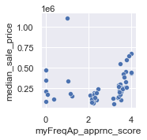

```python
sns.pairplot(df_z2,kind='scatter',x_vars=["myFreqAp_apprnc_score",],
    y_vars=["median_sale_price"])
```

```
                                    -Part H-
             Gentrification & FastFood chain apearance frequency
```

Being inspired by the Starbucks effect , my hypothesis is that the more fast food places an area has the more gentrified it is.

```python
df2 = pd.read_csv('yelp_academic_dataset_business.csv')
df2.head(1)
```

|  | business_id | name | address | city | state | postal_code | latitude | longitude | stars | review_count | is_open | attributes | categories | hours |
| --- | --- | --- | --- | --- | --- | --- | --- | --- | --- | --- | --- | --- | --- | --- |
| 0 | MTSW4McQd7CbVtyjqoe9mw | St Honore Pastries | 935 Race St | Philadelphia | PA | 19107.0 | 39.955505 | -75.155564 | 4.0 | 80 | 1 | {'RestaurantsDelivery': 'False', 'OutdoorSeati... | Restaurants, Food, Bubble Tea, Coffee & Tea, B... | {'Monday': '7:0-20:0', 'Tuesday': '7:0-20:0', ... |

```python
df_h1 = df2.loc[df2['name'].str.contains("McDonald's|Starbucks|Burger King|Chipotle Mexican Grill|Dunkin'|Taco Bell|Domino's|Wendy's|Chick-fil-A|Shake Shack|KFC|Papa John's Pizza|Panda Express|Arby's|Panera Bread|Popeyes Louisiana Kitchen")]
df_h1
```

|  | business_id | name | address | city | state | postal_code | latitude | longitude | stars | review_count | is_open | attributes | categories | hours |
| --- | --- | --- | --- | --- | --- | --- | --- | --- | --- | --- | --- | --- | --- | --- |
| 18 | O1oZpbZNDMH_gz8DhsZCdA | Wendy's | 700 E. Hunting Park | Philadelphia | PA | 19124.0 | 40.012141 | -75.115015 | 1.5 | 15 | 1 | {'RestaurantsTakeOut': 'True', 'RestaurantsPri... | Burgers, Restaurants, Fast Food | {'Monday': '10:0-2:0', 'Tuesday': '10:0-2:0', ... |
| 62 | TGfPJHImEq6AQL9a1laxlg | Chick-fil-A | 9711 Roosevelt Blvd | Philadelphia | PA | 19114.0 | 40.081780 | -75.026791 | 4.0 | 80 | 1 | {'RestaurantsPriceRange2': '1', 'BusinessAccep... | Event Planning & Services, American (Tradition... | {'Monday': '0:0-0:0', 'Tuesday': '10:30-18:0',... |
| 69 | yFqq66GxRjnhZXPgjA6hnw | KFC | 716 Adams Ave | Philadelphia | PA | 19124.0 | 40.031578 | -75.104787 | 2.0 | 7 | 1 | {'OutdoorSeating': 'False', 'WiFi': "'free'", ... | Restaurants, Chicken Shop, Fast Food, Chicken ... | {'Monday': '10:30-23:0', 'Tuesday': '10:30-23:... |
| 74 | kLSEk3qXY1KdtFjxHJ9pww | McDonald's | 501 Franklin Mill Cir | Philadelphia | PA | 19154.0 | 40.088416 | -74.965011 | 1.5 | 20 | 1 | {'BusinessAcceptsCreditCards': 'True', 'Restau... | Restaurants, Fast Food, Food, Coffee & Tea, Bu... | {'Monday': '5:30-0:0', 'Tuesday': '5:30-0:0', ... |
| 171 | kgMEBZG6rjkGeFzPaIM4MQ | McDonald's | 914 S Broad St | Philadelphia | PA | 19146.0 | 39.939440 | -75.166805 | 2.0 | 55 | 0 | {'BusinessAcceptsCreditCards': 'True', 'Restau... | Fast Food, Food, Restaurants, Coffee & Tea, Bu... | {'Monday': '6:0-0:0', 'Tuesday': '6:0-0:0', 'W... |
| ... | ... | ... | ... | ... | ... | ... | ... | ... | ... | ... | ... | ... | ... | ... |
| 14321 | k_mIcCFvXWuN8I4ofCta3g | KFC | 4001 N 5th St | Philadelphia | PA | 19140.0 | 40.012255 | -75.135488 | 1.0 | 5 | 1 | {'DriveThru': 'True', 'RestaurantsTableService... | Restaurants, Chicken Wings, Fast Food, Chicken... | {'Monday': '10:30-0:0', 'Tuesday': '10:30-0:0'... |
| 14411 | pyM8MRVXKDRyhM7tu-3P1A | KFC | 411 W Oregon Ave | Philadelphia | PA | 19148.0 | 39.915113 | -75.155852 | 2.0 | 21 | 1 | {'NoiseLevel': "u'average'", 'RestaurantsGoodF... | Chicken Shop, Restaurants, Fast Food, Chicken ... | {'Monday': '10:30-20:0', 'Tuesday': '10:30-20:... |
| 14479 | 6liIxwAycRwnzefTVqGGEw | Panera Bread | 3900 City Ave | Philadelphia | PA | 19131.0 | 40.008302 | -75.209764 | 2.0 | 55 | 1 | {'RestaurantsTakeOut': 'True', 'RestaurantsAtt... | Salad, Sandwiches, Bakeries, Restaurants, Food... | {'Monday': '7:0-21:0', 'Tuesday': '7:0-21:0', ... |
| 14486 | bh60ZTqnciiH3FlTUJ-6iw | Dunkin' | 9490 Blue Grass Rd | Philadelphia | PA | 19114.0 | 40.078790 | -75.025854 | 1.5 | 12 | 1 | {'BusinessAcceptsCreditCards': 'True', 'BikePa... | Food, Donuts, Bagels, Bakeries, Coffee & Tea | {'Monday': '0:0-0:0', 'Tuesday': '0:0-0:0', 'W... |
| 14546 | pM1M2A14mNXz48KCcQtz2w | Starbucks | 4140 Woodland Ave | Philadelphia | PA | 19104.0 | 39.946809 | -75.206722 | 3.0 | 17 | 1 | {'BusinessAcceptsCreditCards': 'True', 'Restau... | Food, Coffee & Tea | {'Monday': '0:0-0:0', 'Tuesday': '7:0-23:0', '... |

342 rows × 14 columns

```python
df_h1 = df_h1[df_h1['postal_code'].notnull()]
df_h1['postal_code'] = df_h1['postal_code'].apply(np.int64)
```

```python
df_h1
```

|  | business_id | name | address | city | state | postal_code | latitude | longitude | stars | review_count | is_open | attributes | categories | hours |
| --- | --- | --- | --- | --- | --- | --- | --- | --- | --- | --- | --- | --- | --- | --- |
| 18 | O1oZpbZNDMH_gz8DhsZCdA | Wendy's | 700 E. Hunting Park | Philadelphia | PA | 19124 | 40.012141 | -75.115015 | 1.5 | 15 | 1 | {'RestaurantsTakeOut': 'True', 'RestaurantsPri... | Burgers, Restaurants, Fast Food | {'Monday': '10:0-2:0', 'Tuesday': '10:0-2:0', ... |
| 62 | TGfPJHImEq6AQL9a1laxlg | Chick-fil-A | 9711 Roosevelt Blvd | Philadelphia | PA | 19114 | 40.081780 | -75.026791 | 4.0 | 80 | 1 | {'RestaurantsPriceRange2': '1', 'BusinessAccep... | Event Planning & Services, American (Tradition... | {'Monday': '0:0-0:0', 'Tuesday': '10:30-18:0',... |
| 69 | yFqq66GxRjnhZXPgjA6hnw | KFC | 716 Adams Ave | Philadelphia | PA | 19124 | 40.031578 | -75.104787 | 2.0 | 7 | 1 | {'OutdoorSeating': 'False', 'WiFi': "'free'", ... | Restaurants, Chicken Shop, Fast Food, Chicken ... | {'Monday': '10:30-23:0', 'Tuesday': '10:30-23:... |
| 74 | kLSEk3qXY1KdtFjxHJ9pww | McDonald's | 501 Franklin Mill Cir | Philadelphia | PA | 19154 | 40.088416 | -74.965011 | 1.5 | 20 | 1 | {'BusinessAcceptsCreditCards': 'True', 'Restau... | Restaurants, Fast Food, Food, Coffee & Tea, Bu... | {'Monday': '5:30-0:0', 'Tuesday': '5:30-0:0', ... |
| 171 | kgMEBZG6rjkGeFzPaIM4MQ | McDonald's | 914 S Broad St | Philadelphia | PA | 19146 | 39.939440 | -75.166805 | 2.0 | 55 | 0 | {'BusinessAcceptsCreditCards': 'True', 'Restau... | Fast Food, Food, Restaurants, Coffee & Tea, Bu... | {'Monday': '6:0-0:0', 'Tuesday': '6:0-0:0', 'W... |
| ... | ... | ... | ... | ... | ... | ... | ... | ... | ... | ... | ... | ... | ... | ... |
| 14321 | k_mIcCFvXWuN8I4ofCta3g | KFC | 4001 N 5th St | Philadelphia | PA | 19140 | 40.012255 | -75.135488 | 1.0 | 5 | 1 | {'DriveThru': 'True', 'RestaurantsTableService... | Restaurants, Chicken Wings, Fast Food, Chicken... | {'Monday': '10:30-0:0', 'Tuesday': '10:30-0:0'... |
| 14411 | pyM8MRVXKDRyhM7tu-3P1A | KFC | 411 W Oregon Ave | Philadelphia | PA | 19148 | 39.915113 | -75.155852 | 2.0 | 21 | 1 | {'NoiseLevel': "u'average'", 'RestaurantsGoodF... | Chicken Shop, Restaurants, Fast Food, Chicken ... | {'Monday': '10:30-20:0', 'Tuesday': '10:30-20:... |
| 14479 | 6liIxwAycRwnzefTVqGGEw | Panera Bread | 3900 City Ave | Philadelphia | PA | 19131 | 40.008302 | -75.209764 | 2.0 | 55 | 1 | {'RestaurantsTakeOut': 'True', 'RestaurantsAtt... | Salad, Sandwiches, Bakeries, Restaurants, Food... | {'Monday': '7:0-21:0', 'Tuesday': '7:0-21:0', ... |
| 14486 | bh60ZTqnciiH3FlTUJ-6iw | Dunkin' | 9490 Blue Grass Rd | Philadelphia | PA | 19114 | 40.078790 | -75.025854 | 1.5 | 12 | 1 | {'BusinessAcceptsCreditCards': 'True', 'BikePa... | Food, Donuts, Bagels, Bakeries, Coffee & Tea | {'Monday': '0:0-0:0', 'Tuesday': '0:0-0:0', 'W... |
| 14546 | pM1M2A14mNXz48KCcQtz2w | Starbucks | 4140 Woodland Ave | Philadelphia | PA | 19104 | 39.946809 | -75.206722 | 3.0 | 17 | 1 | {'BusinessAcceptsCreditCards': 'True', 'Restau... | Food, Coffee & Tea | {'Monday': '0:0-0:0', 'Tuesday': '7:0-23:0', '... |

342 rows × 14 columns

```python
df_h2 = df_h1.groupby(["postal_code",], as_index=False)["name"].count()
df_h2.head()
```

|  | postal_code | name |
| --- | --- | --- |
| 0 | 19102 | 15 |
| 1 | 19103 | 16 |
| 2 | 19104 | 26 |
| 3 | 19106 | 6 |
| 4 | 19107 | 23 |

```python
df_h3 = pd.read_table('RedfinPhila.tsv')
pd.set_option('display.max_columns', None)

df_h3.head()
```

|  | period_begin | period_end | period_duration | region_type | region_type_id | table_id | is_seasonally_adjusted | region | city | state | state_code | property_type | property_type_id | median_sale_price | median_sale_price_mom | median_sale_price_yoy | median_list_price | median_list_price_mom | median_list_price_yoy | median_ppsf | median_ppsf_mom | median_ppsf_yoy | median_list_ppsf | median_list_ppsf_mom | median_list_ppsf_yoy | homes_sold | homes_sold_mom | homes_sold_yoy | pending_sales | … |
| --- | --- | --- | --- | --- | --- | --- | --- | --- | --- | --- | --- | --- | --- | --- | --- | --- | --- | --- | --- | --- | --- | --- | --- | --- | --- | --- | --- | --- | --- | --- |
| 0 | 2016-10-01 | 2016-12-31 | 90 | zip code | 2 | 7365 | f | Zip Code: 19070 | NaN | Pennsylvania | PA | Townhouse | 13 | 252438.0 | 0.000000 | 0.022662 | 256959.0 | -0.011485 | -0.065517 | 130.785204 | 0.015453 | -0.070149 | 139.032517 | 0.000575 | -0.010869 | 4 | -0.20000 | -0.428571 | 1.0 | … |
| 1 | 2022-03-01 | 2022-05-31 | 90 | zip code | 2 | 7371 | f | Zip Code: 19078 | NaN | Pennsylvania | PA | Multi-Family (2-4 Unit) | 4 | 580000.0 | 0.000000 | 1.274510 | 297500.0 | -0.502050 | NaN | 133.795380 | -0.067538 | NaN | 131.138357 | 0.005947 | NaN | 3 | 0.00000 | 2.000000 | NaN | … |
| 2 | 2016-12-01 | 2017-02-28 | 90 | zip code | 2 | 7345 | f | Zip Code: 19043 | NaN | Pennsylvania | PA | Single Family Residential | 6 | 219900.0 | 0.231933 | 0.470903 | 166950.0 | 0.095117 | -0.239234 | 160.436137 | 0.299777 | 0.314408 | 129.100737 | 0.106436 | 0.057198 | 7 | -0.30000 | 0.000000 | 2.0 | … |
| 3 | 2013-06-01 | 2013-08-31 | 90 | zip code | 2 | 7413 | f | Zip Code: 19124 | NaN | Pennsylvania | PA | All Residential | -1 | 55125.0 | -0.096311 | -0.177239 | 74900.0 | 0.000000 | 0.070000 | 51.058077 | -0.045148 | -0.146309 | 64.984709 | -0.024009 | 0.068242 | 126 | 0.02439 | 0.058824 | 36.0 | … |
| 4 | 2016-11-01 | 2017-01-31 | 90 | zip code | 2 | 7413 | f | Zip Code: 19124 | NaN | Pennsylvania | PA | Multi-Family (2-4 Unit) | 4 | 69000.0 | -0.366972 | 0.254545 | 159945.0 | -0.189926 | 1.104539 | 41.045619 | -0.458097 | 0.098530 | 94.119817 | 0.203270 | 0.754393 | 2 | 0.00000 | -0.333333 | 2.0 | … |

By looking through the collumns i couldnt find any attributes that are applicable to famous metrics of defining gentrification like the Ellen & O’Regan model. It is a known fact that gentrification raises the prices the market value of real estate. For simplicity purposes: high median_sale_price equals highly gentrified.

```python
df_h3 = df_h3[['region', 'median_sale_price']]
df_h4 =df_h3.groupby(["region"], as_index=False)["median_sale_price"].median()
#manipulate 'region' to fit with the postal_code from the other dataframe
df_h4['region'] = df_h4['region'].astype('str').str.extractall('(\d+)').unstack().fillna('').sum(axis=1).astype(int)
df_h4 = df_h4.rename(columns={'region': 'postal_code'})
df_h4
```

|  | postal_code | median_sale_price |
| --- | --- | --- |
| 0 | 19003 | 310000.0 |
| 1 | 19008 | 323000.0 |
| 2 | 19010 | 466250.0 |
| 3 | 19013 | 40000.0 |
| 4 | 19014 | 202062.5 |
| ... | ... | ... |
| 101 | 44680 | 161075.0 |
| 102 | 44681 | 154500.0 |
| 103 | 44682 | 94000.0 |
| 104 | 44683 | 72900.0 |
| 105 | 44697 | 219500.0 |

106 rows × 2 columns

```python
df_h5 = df_h4.merge(df_h2, on='postal_code')
df_h5 = df_h5.rename({'name': 'fast_food_freq'}, axis=1)
df_h5.head()
```

|  | postal_code | median_sale_price | fast_food_freq |
| --- | --- | --- | --- |
| 0 | 19102 | 510000.0 | 15 |
| 1 | 19103 | 491125.0 | 16 |
| 2 | 19104 | 221250.0 | 26 |
| 3 | 19106 | 414625.0 | 6 |
| 4 | 19107 | 334687.5 | 23 |

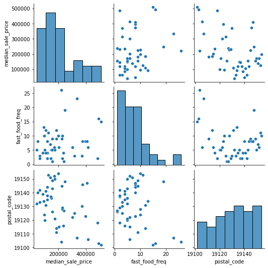

```python
sns.pairplot(df_h5,kind='scatter',x_vars=["median_sale_price", "fast_food_freq",'postal_code'],
    y_vars=["median_sale_price","fast_food_freq",'postal_code'])
```

```python
df_h5[['median_sale_price','fast_food_freq']].corr()
```

|  | median_sale_price | fast_food_freq |
| --- | --- | --- |
| median_sale_price | 1.000000 | 0.230805 |
| fast_food_freq | 0.230805 | 1.000000 |

```python
calculate_pvalues(df_h5[['median_sale_price','fast_food_freq']])
```

|  | median_sale_price | fast_food_freq |
| --- | --- | --- |
| median_sale_price | 0.0 | 0.1272 |
| fast_food_freq | 0.1272 | 0.0 |

Looking at the p-value (p-value > 0.05) ,indicates that the evidence is not strong enough to suggest that the hypothesis could be correct but there might be a slight correlation. (correlation coefficient table).The plot (x: fast_food_freq , y:median_sale_price) might suggest that the less frequent the fast foods chains in an area the less expensive it is.

Who knew, maybe gentrification is not that bad after all ＼(٥⁀▽⁀ )／